# Identifying images using the universal workflow of machine learning

## Methodology

As stated by Chollet in Deep Learing with Python, 3.3 *Setting up a deep-learning workstation*, it is "highly recommended, although not strictly necessary, that you run deep-learning code on a modern NVIDIA GPU" <sup>1</sup>. With this in mind, and with Chollet's later recommendation of running our experiements in the cloud, I am utilising Google Colab for this project, with the GPU hardware accelerator turned on.

We start by importing the libraries that we will need for our experiments.

```python
# numpy for math functions and matplotlib for plotting functions
import numpy as np
import matplotlib.pyplot as plt

# tensorflow and it's datasets
import tensorflow as tf
import tensorflow_datasets as tfds

# disable the loading info to keep our report clean
tfds.disable_progress_bar()

# keras
from tensorflow import keras
from tensorflow.keras import models, layers

# sklearn

from sklearn.metrics import confusion_matrix, classification_report
```

### 1. Load Data

Now we have the necessary libraries, we can grab our data, using the TensorFlow API, using the split attribute of the load function to get the train and test sets.

```python
tf_dataset_name = 'cifar10'

# Load the train images, using the train split
train_dataset, info = tfds.load(name=tf_dataset_name, with_info=True, split="train")
# Load the train images, using the train split
test_dataset, info = tfds.load(name=tf_dataset_name, with_info=True, split="test")
```

We can now examine our data.

```python
# Output the dataset information
info
```

```
tfds.core.DatasetInfo(
    name='cifar10',
    version=3.0.2,
    description='The CIFAR-10 dataset consists of 60000 32x32 colour images in 10 classes, with 6000 images per class. There are 50000 training images and 10000 test images.',
    homepage='https://www.cs.toronto.edu/~kriz/cifar.html',
    features=FeaturesDict({
        'id': Text(shape=(), dtype=tf.string),
        'image': Image(shape=(32, 32, 3), dtype=tf.uint8),
        'label': ClassLabel(shape=(), dtype=tf.int64, num_classes=10),
    }),
    total_num_examples=60000,
    splits={
        'test': 10000,
        'train': 50000,
    },
    supervised_keys=('image', 'label'),
    citation="""@TECHREPORT{Krizhevsky09learningmultiple,
        author = {Alex Krizhevsky},
        title = {Learning multiple layers of features from tiny images},
        institution = {},
        year = {2009}
    }""",
    redistribution_info=,
)
```

Pulling out some inforomation of note, we have:

- 60000 sample images
- These images are split 50000 train images and 10000 test images
- Each image is 32 x 32, with three colour channels (RGB)

```python
# Print the class names
class_names = info.features['label'].names
print('Class names:')
print(class_names)
```

```
Class names:
['airplane', 'automobile', 'bird', 'cat', 'deer', 'dog', 'frog', 'horse', 'ship', 'truck']
```

The images are spread across 10 classes.

The TensorFlow API gives us an option to visualise images and labels from an image classification dataset.

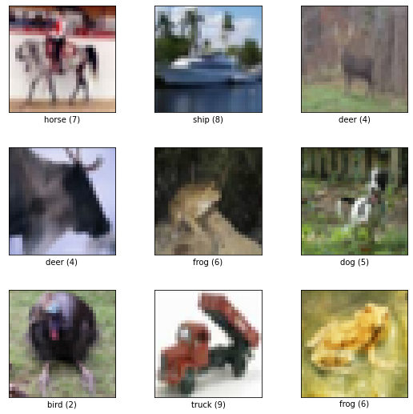

```python
# Show example images from the train set
fig = tfds.show_examples(train_dataset, info)
```

### 2. Preprocess Data

Now we need to preprocess our images so that they in a format that our model with expect. Let's look at our data in a little more detail.

```python
ds = train_dataset.take(1)

for example in ds:
  print(list(example.keys()))
```

```
['id', 'image', 'label']
```

We can see that each tf.Tensor in the tf.data.Dataset contains an id, an image and a label. We'll extract them into two seperate lists (we are not concerned with the id), for our train data and test data respectively.

```python
train_images = list()
train_labels = list()

for example in train_dataset:
  train_images.append(example['image'].numpy()) # Call .numpy() to convertt to np.array
  train_labels.append(example['label'].numpy()) # Call .numpy() to convertt to np.array

train_images = np.array(train_images) # Convert to np.array
train_labels = np.array(train_labels) # Convert to np.array

test_images = list()
test_labels = list()

for example in test_dataset:
  test_images.append(example['image'].numpy()) # Call .numpy() to convertt to np.array
  test_labels.append(example['label'].numpy()) # Call .numpy() to convertt to np.array

test_images = np.array(test_images) # Convert to np.array
test_labels = np.array(test_labels) # Convert to np.array
```

Now we need to convert the types to floats, and standardise the RGB channel values from [0, 255] to be in the range [0, 1]. We could do this using ImageDataGenerator from keras, but that feels like too much as the only thing we want to change is to scale the RGB values.

```python
train_images = train_images.astype('float32') / 255
test_images = test_images.astype('float32') / 255
```

### 3. Build Network

Now we have preprocessed our data, we are ready to build our first neural network.

```python
# Initialise an empty network
network = models.Sequential()

# Add layers
network.add(layers.Conv2D(16, 3, padding='same', activation='relu'))
network.add(layers.MaxPooling2D())
network.add(layers.Conv2D(32, 3, padding='same', activation='relu'))
network.add(layers.MaxPooling2D())
network.add(layers.Conv2D(64, 3, padding='same', activation='relu'))
network.add(layers.MaxPooling2D())
layers.Dropout(0.2)
network.add(layers.Flatten())
network.add(layers.Dense(128, activation='relu'))
network.add(layers.Dense(10, activation='softmax'))

# Output summary
network.build((None, 32, 32, 3))
network.summary()

# Prepare network
optimiser = 'adam'
loss_function = keras.losses.SparseCategoricalCrossentropy()
metrics = ['accuracy']

network.compile(optimizer=optimiser,
                loss=loss_function,
                metrics=metrics)
```

```
Model: "sequential"
_________________________________________________________________
 Layer (type)                Output Shape              Param #
=================================================================
 conv2d (Conv2D)             (None, 32, 32, 16)        448

 max_pooling2d (MaxPooling2D  (None, 16, 16, 16)       0
 )

 conv2d_1 (Conv2D)           (None, 16, 16, 32)        4640

 max_pooling2d_1 (MaxPooling  (None, 8, 8, 32)         0
 2D)

 conv2d_2 (Conv2D)           (None, 8, 8, 64)          18496

 max_pooling2d_2 (MaxPooling  (None, 4, 4, 64)         0
 2D)

 flatten (Flatten)           (None, 1024)              0

 dense (Dense)               (None, 128)               131200

 dense_1 (Dense)             (None, 10)                1290

=================================================================
Total params: 156,074
Trainable params: 156,074
Non-trainable params: 0
_________________________________________________________________
```

### 4. Train

```python
# Create our validation set for images
val_images = train_images[:10000]
partial_train_images = train_images[10000:]
# Create our validation set for labels
val_labels = train_labels[:10000]
partial_train_labels = train_labels[10000:]

# Train the model
epochs = 20
batch_size = 128

result_1 = network.fit(partial_train_images,
                    partial_train_labels,
                    epochs=epochs,
                    validation_data=(val_images, val_labels))
```

## Results

```python
# Plotting utils

## Accouracy
def plot_acc(hist):
    plt.plot(hist.history['accuracy'])
    plt.plot(hist.history['val_accuracy'])
    plt.title('Training and validation accuracy')
    plt.ylabel('Accuracy')
    plt.xlabel('Epochs')
    plt.legend(['Training acc', 'Validation acc'], loc='upper left')
    plt.show()
    plt.clf()

## Loss
def plot_loss(hist):
    plt.plot(hist.history['loss'])
    plt.plot(hist.history['val_loss'])
    plt.title('Training and validation loss')
    plt.ylabel('Loss')
    plt.xlabel('Epochs')
    plt.legend(['Training loss', 'Validation loss'], loc='upper left')
    plt.show()
    plt.clf()
```

### 5. Test *

* And possibly retrain.

We can now test our model. Let's look at how acccurate was with some visualisations.

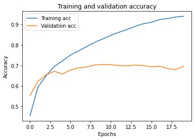

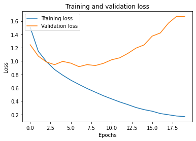

```
[0.11388182640075684, 0.9597749710083008]
```

```python
plot_acc(result_1)
plot_loss(result_1)
network.evaluate(partial_train_images, partial_train_labels)
```

```python
network.evaluate(test_images, test_labels)
```

```
[1.7267011404037476, 0.6881999969482422]
```

And there we have it. On unseen data - the test set - our model only reaches an accuracy of 68%.

I tweaked a number of parameters in the above model - including stopping after only two epochs - but I wasn't able to improve on the earier scores. After some further research, I discovered a model that uses *BatchNormalization*<sup>10</sup>. *BatchNormalization* is "a technique for training very deep neural networks that standardizes the inputs to a layer for each mini-batch." <sup>11</sup>

```python
from ssl import CHANNEL_BINDING_TYPES
# Initialise an empty network
network = models.Sequential()

# Add new layers
network.add(layers.Conv2D(64,(4,4),input_shape=(32,32,3),activation='relu',padding='same'))
network.add(layers.BatchNormalization())
network.add(layers.Conv2D(64,(4,4),input_shape=(32,32,3),activation='relu',padding='same'))
network.add(layers.BatchNormalization())
network.add(layers.MaxPooling2D(pool_size=(2,2)))
network.add(layers.Dropout(0.2))
network.add(layers.Conv2D(128,(4,4),input_shape=(32,32,3),activation='relu',padding='same'))
network.add(layers.BatchNormalization())
network.add(layers.Conv2D(128,(4,4),input_shape=(32,32,3),activation='relu',padding='same'))
network.add(layers.BatchNormalization())
network.add(layers.MaxPooling2D(pool_size=(2,2)))
network.add(layers.Dropout(0.25))
network.add(layers.Conv2D(128,(4,4),input_shape=(32,32,3),activation='relu',padding='same'))
network.add(layers.BatchNormalization())
network.add(layers.Conv2D(128,(4,4),input_shape=(32,32,3),activation='relu',padding='same'))
network.add(layers.BatchNormalization())
network.add(layers.MaxPooling2D(pool_size=(2,2)))
network.add(layers.Dropout(0.35))
network.add(layers.Flatten())
network.add(layers.Dense(256, activation='relu'))
network.add(layers.BatchNormalization())
network.add(layers.Dropout(0.5))
network.add(layers.Dense(len(class_names), activation='softmax'))

# Output summary
network.summary()

# Prepare network
optimiser = 'adam'
loss_function = keras.losses.SparseCategoricalCrossentropy()
metrics = ['accuracy']

network.compile(optimizer=optimiser,
                loss=loss_function,
                metrics=metrics)
```

```
Model: "sequential_1"
_________________________________________________________________
 Layer (type)                Output Shape              Param #
=================================================================
 conv2d_3 (Conv2D)           (None, 32, 32, 64)        3136

 batch_normalization (BatchN  (None, 32, 32, 64)       256
 ormalization)

 conv2d_4 (Conv2D)           (None, 32, 32, 64)        65600

 batch_normalization_1 (Batc  (None, 32, 32, 64)       256
 hNormalization)

 max_pooling2d_3 (MaxPooling  (None, 16, 16, 64)       0
 2D)

 dropout_1 (Dropout)         (None, 16, 16, 64)        0

 conv2d_5 (Conv2D)           (None, 16, 16, 128)       131200

 batch_normalization_2 (Batc  (None, 16, 16, 128)      512
 hNormalization)

 conv2d_6 (Conv2D)           (None, 16, 16, 128)       262272

 batch_normalization_3 (Batc  (None, 16, 16, 128)      512
 hNormalization)

 max_pooling2d_4 (MaxPooling  (None, 8, 8, 128)        0
 2D)

 dropout_2 (Dropout)         (None, 8, 8, 128)         0

 conv2d_7 (Conv2D)           (None, 8, 8, 128)         262272

 batch_normalization_4 (Batc  (None, 8, 8, 128)        512
 hNormalization)

 conv2d_8 (Conv2D)           (None, 8, 8, 128)         262272
```

[output cut: 10 more lines]

```

 dense_2 (Dense)             (None, 256)               524544

 batch_normalization_6 (Batc  (None, 256)              1024
 hNormalization)

 dropout_4 (Dropout)         (None, 256)               0

 dense_3 (Dense)             (None, 10)                2570

=================================================================
Total params: 1,517,450
Trainable params: 1,515,658
Non-trainable params: 1,792
_________________________________________________________________
```

We'll now train this model, using 20 epochs, and a batch size of 128.

```python
# Create our validation set for images
val_images = train_images[:10000]
partial_train_images = train_images[10000:]
# Create our validation set for labels
val_labels = train_labels[:10000]
partial_train_labels = train_labels[10000:]

# Train the model
epochs = 20
batch_size = 128

result_2 = network.fit(partial_train_images,
                    partial_train_labels,
                    epochs=epochs,
                    batch_size=batch_size,
                    validation_data=(val_images, val_labels))
```

```python
# Evaluate on train set
network.evaluate(partial_train_images, partial_train_labels)
```

```
[0.06200524792075157, 0.9794250130653381]
```

```python
scores = network.evaluate(test_images, test_labels, verbose=1)
print('Test loss:', scores[0])
print('Test accuracy:', scores[1])
```

```
Test loss: 0.6824102401733398
Test accuracy: 0.8317999839782715
```

```python
R = 5
C = 5
fig, axes = plt.subplots(R, C, figsize=(12,12))
axes = axes.ravel()

train_labels = keras.utils.to_categorical(train_labels, len(class_names))
test_labels = keras.utils.to_categorical(test_labels, len(class_names))

pred = network.predict(test_images)

Y_pred_classes = np.argmax(pred, axis=1)
Y_true = np.argmax(test_labels, axis=1)

labels = ['Airplane', 'Automobile', 'Bird', 'Cat', 'Deer', 'Dog', 'Frog', 'Horse', 'Ship', 'Truck']

#print(classification_report(Y_true, Y_pred_classes))


# axes[i].set_title("True: %s \nPredict: %s" % (class_names[Y_true[i]], labels[Y_pred_classes[i]]))


for i in np.arange(0, R*C):
    axes[i].imshow(test_images[i])
    #axes[i].set_title("True: %s \nPredict: %s" % (class_names[Y_true[i]], labels[Y_pred_classes[i]]))
    axes[i].set_title("True: %s \nPredict: %s" % (labels[Y_true[i]], labels[Y_pred_classes[i]]))
    axes[i].axis('off')
    plt.subplots_adjust(wspace=1)
```

[output not shown]

## Conclusions

#### References

1. Deep Learning with Python, Francois Chollet, 2018, Manning Publications.
2. CIFAR-10 | Image Classification | Using CNN https://www.kaggle.com/devsubhash/cifar-10-image-classification-using-cnn
3. tf.keras.layers.Conv2D https://www.tensorflow.org/api_docs/python/tf/keras/layers/Conv2D
4. tf.keras.layers.MaxPool2D https://www.tensorflow.org/api_docs/python/tf/keras/layers/MaxPool2D
5. tf.keras.layers.Dense https://www.tensorflow.org/api_docs/python/tf/keras/layers/Dense
6. Rectifier https://en.wikipedia.org/wiki/Rectifier_(neural_networks)
7. Dropout later https://keras.io/api/layers/regularization_layers/dropout/
8. Deep Learning with Python, Francois Chollet, 2018, Manning Publications.
9. Softmax Activation Function https://machinelearningmastery.com/softmax-activation-function-with-python/
10. Batch Normalization in practice: an example with Keras and TensorFlow 2.0 https://towardsdatascience.com/batch-normalization-in-practice-an-example-with-keras-and-tensorflow-2-0-b1ec28bde96f
11. A Gentle Introduction to Batch Normalization for Deep Neural Networks https://machinelearningmastery.com/batch-normalization-for-training-of-deep-neural-networks/